# assignment_3

David Langenohl

08.11.2019

1. Read the data provided in the Excel file and “isolate” the tabulated information into a *data.frame* class.

```r
df <- read.table(paste0(envrmt$path_data, "hessen_holzeinschlag_1997-2014.csv"),
                 skip = 4,
                 header = T,
                 sep = ";",
                 dec = ".")

df <- df[-c(nrow(df)),] #delete last row, as it does not contain data we want
```

2. Create a simple visualization which gives a quick, temporally non explicit and descriptive statistical overview of the harvest by tree type and as a total over all trees (i.e. a similar kind of information as provided by the summary function).

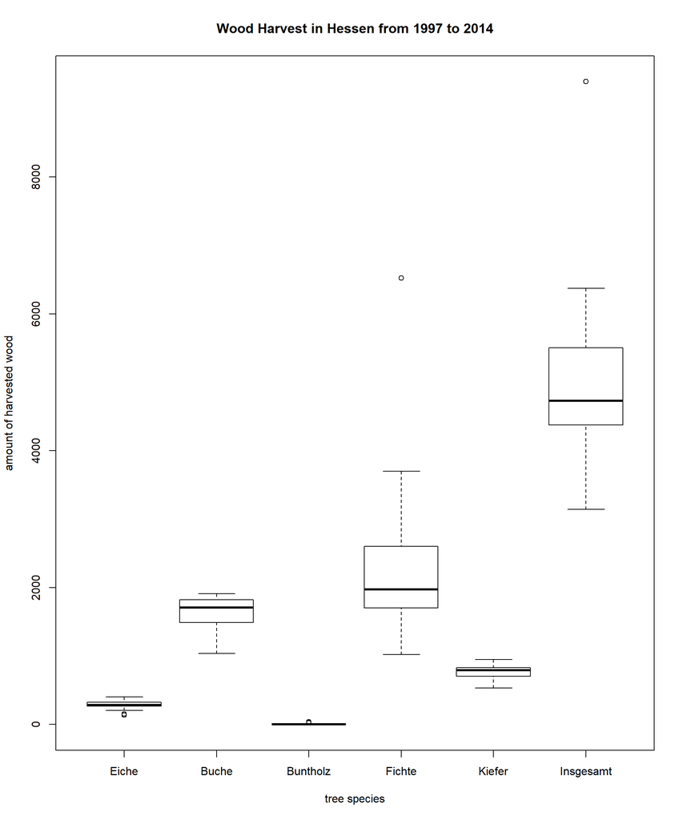

```r
boxplot <- boxplot(df[,-1], row.names = T,
                   main = "Wood Harvest in Hessen from 1997 to 2014",
                   xlab = "tree species",
                   ylab = "amount of harvested wood")
```

3. Create another visualization which - in the same figure panel - shows how each beech harvest over the time span is related to each of the oak, pine, spruce and colored wood harvests in a 2 by 2 grid (i.e. arrange the figures in a 2 columns and 2 rows layout).

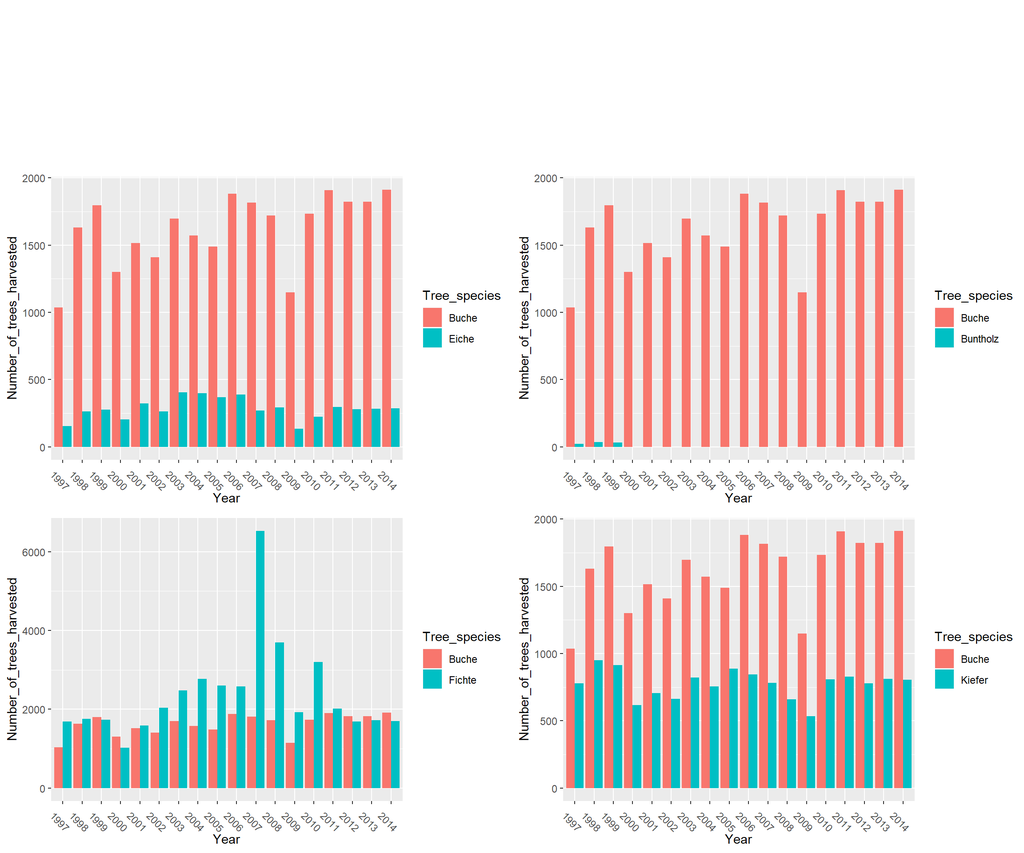

```r
#fig.width and fig.height are used to expand the size of the image, when it is knitted
#packages used: ggplot2, reshape2, cowplot (as mfrow does not work with ggplot2 plots)
df2 <- melt(df[, c("FWJ", "Buche", "Eiche")], id.vars = "FWJ")
names(df2) <- c("Year", "Tree_species", "Number_of_trees_harvested")
plot1 <- ggplot(df2, aes(x=Year, y = Number_of_trees_harvested, fill = Tree_species)) +
  geom_bar(stat = "identity", position = "dodge") +
  theme(axis.text.x = element_text(angle = -45))

df2 <- melt(df[, c("FWJ", "Buche", "Buntholz")], id.vars = "FWJ")
names(df2) <- c("Year", "Tree_species", "Number_of_trees_harvested")
plot2 <- ggplot(df2, aes(x=Year, y = Number_of_trees_harvested, fill = Tree_species)) +
  geom_bar(stat = "identity", position = "dodge") +
  theme(axis.text.x = element_text(angle = -45))

df2 <- melt(df[, c("FWJ", "Buche", "Fichte")], id.vars = "FWJ")
names(df2) <- c("Year", "Tree_species", "Number_of_trees_harvested")
plot3 <- ggplot(df2, aes(x=Year, y = Number_of_trees_harvested, fill = Tree_species)) +
  geom_bar(stat = "identity", position = "dodge") +
  theme(axis.text.x = element_text(angle = -45))

df2 <- melt(df[, c("FWJ", "Buche", "Kiefer")], id.vars = "FWJ")
names(df2) <- c("Year", "Tree_species", "Number_of_trees_harvested")
plot4 <- ggplot(df2, aes(x=Year, y = Number_of_trees_harvested, fill = Tree_species)) +
  geom_bar(stat = "identity", position = "dodge") +
  theme(axis.text.x = element_text(angle = -45))

ggdraw(xlim = c(0,2), ylim = c(0,1.25)) +
  draw_plot(plot1, x = 0, y = .5, width = 1, height = .5) +
  draw_plot(plot2, x = 1, y = .5, width = 1, height = .5) +
  draw_plot(plot3, x = 0, y = 0, width = 1, height = .5) +
  draw_plot(plot4, x = 1, y = 0, width = 1, height = .5)
```

4. Include your opinion on what could be the key message of these figures in two sentence max.